# Session 10 Cluster Analysis

[**CCMVI2085U Machine Learning for Predictive Analytics in Business @ CBS ISUP 2020**](https://kursuskatalog.cbs.dk/2019-2020/KAN-CCMVI2085U.aspx?lang=en-GB)

Course coordinator: [Bowei Chen](https://boweichen.github.io/) | Email: bc.acc@cbs.dk

Today we are going to study cluster analysis (or in short clustering). It is a popular type of unsupervised learning methods which has been widely used in business analytics such as consumer segmentation, trading pattern recognition and so on.

# Table of Contents

## What is cluster analysis?

Cluster analysis methods seek to find groups of closely related instances/observations so that instances/observations that belong to the same cluster are more similar to each other than those that belong to other clusters.

Let's set up the mathematical notations at the beginning. We denote the dataset $\mathscr{D}$, where

$$\mathscr{D} = \{\boldsymbol{x}_1, \cdots, \boldsymbol{x}_N\} = \{\boldsymbol{x}_n\}_{n=1}^{N}$$$$ \boldsymbol{X} = \left[ \begin{array}{ccc} x_{11} & \cdots & x_{1D} \\ \vdots & \ddots & \vdots \\ x_{N1} & \cdots & x_{ND} \\ \end{array} \right] = \left[ \begin{array}{c} \boldsymbol{x}_1^\top \\ \vdots\\ \boldsymbol{x}_N^\top \\ \end{array} \right]$$

They are several types of clustering methods, including:

- Hierarchical clustering (nested)
- Partitioning clustering (unnested)

[figure not shown]

## Motivating example

Dataset `Purchase_Consumer_Segmentation.csv` contains two variables:

- Average spending shows the average amount that a customer spends at the supermarket (chain store)
- Number of purchases shows the total number of purchases made by the customer in last three months

Note: it is a synthetic data that I created based on the Old Faithful dataset.

|  | Average spending | Number of purchases |
| --- | --- | --- |
| 0 | 3.600 | 79 |
| 1 | 1.800 | 54 |
| 2 | 3.333 | 74 |
| 3 | 2.283 | 62 |
| 4 | 4.533 | 85 |

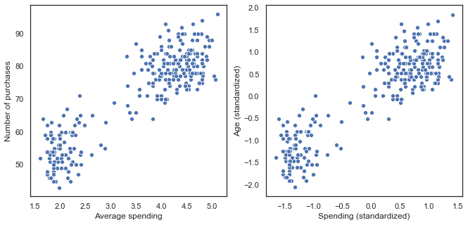

After performing descrptive analytics, we can assume there are two groups/clusters.

## K-means clustering

### Basic idea

For each data point $\boldsymbol{x}_n$, we introduce a corresponding set of binary indicator variables $r_{nk} \in \{0,1\}$, where $k = 1,...,K$ describing which of the $K$ clusters the data point $\boldsymbol{x}_n$ is assigned to, so that if data point $\boldsymbol{x}_n$ is assigned to cluster $k$ then $r_{nk} = 1$, and $r_{nj} = 0$ for $j \neq k$.

We can then define an objective function, sometimes called a **distortion measure**, given by

$$ J = \sum_{n=1}^{N} \sum_{k=1}^{K} r_{nk} \parallel\boldsymbol{x}_n - \boldsymbol{\mu}_k \parallel_2^2, $$

which represents the sum of the squares of the distances of each data point to its assigned vector $\boldsymbol{\mu}_k$, where

$$ \parallel\boldsymbol{x}_n - \boldsymbol{\mu}_k\parallel_2^2 = (\boldsymbol{x}_n - \boldsymbol{\mu}_k)^\top (\boldsymbol{x}_n - \boldsymbol{\mu}_k) = \sum_{d = 1}^D (x_n^{\{d\}} - \mu_k^{\{d\}})^2. $$

Our goal is to find values for the $\{r_{nk}\}$ and the $\{\boldsymbol{\mu}_k\}$ so as to minimize $J$.

### How does k-means clustering work?

We can do this through an iterative procedure in which each iteration involves two successive steps corresponding to successive optimizations with respect to $r_{nk}$ and $\boldsymbol{\mu}_k$.

**Input**: $\mathscr{D} = \{\boldsymbol{x}_n\}_{n=1}^{N}$
**Process**:
1: **Choose** some initial values for the $\boldsymbol{\mu}_k$
2: **Minimize** $J$ with respect to $r_{nk}$, keeping the $\boldsymbol{\mu}_k$ fixed:
$$ \hat{k}_n = \textrm{argmin}_{j \in \{1, \cdots, K\}} ||\boldsymbol{x}_n - \boldsymbol{\mu}_j||_2^2, $$ $$ r_{nk} = \bigg\{ \begin{array} $1, \textrm{ if } \hat{k}_n = k,\\ 0, \textrm{ Otherwise}.\\ \end{array} $$ 3: **Minimize** $J$ with respect to $\boldsymbol{\mu}_k$, keeping $r_{nk}$ fixed (if $\sum_n r_{nk} = 0$, then we leave the mean $\boldsymbol{\mu}_k$ where it is): $$ \boldsymbol{\mu}_k = \frac{\sum_n r_{nk} \boldsymbol{x}_n }{ \sum_n r_{nk}}. $$ 2: **Repeat** Steps 2 and 3 until $J$ converges.
**Output**: $r_{nk}, \boldsymbol{\mu}_{k}$

Step 2 is also called the **assignment step** and Step 3 is called the **update step**. K-means is EM’ish (i.e., Expectation-Maximisation algorithm, shortly EM algorithm), but makes "hard" assignments of $\boldsymbol{x}_n$ to clusters. The two phases of re-assigning data points to clusters and re-computing the cluster means are repeated in turn until there is no further change in the assignments (or until some maximum number of iterations is exceeded). Because each phase reduces the value of the objective function $J$, convergence of the algorithm is assured. (see Bishop Chapter 9)

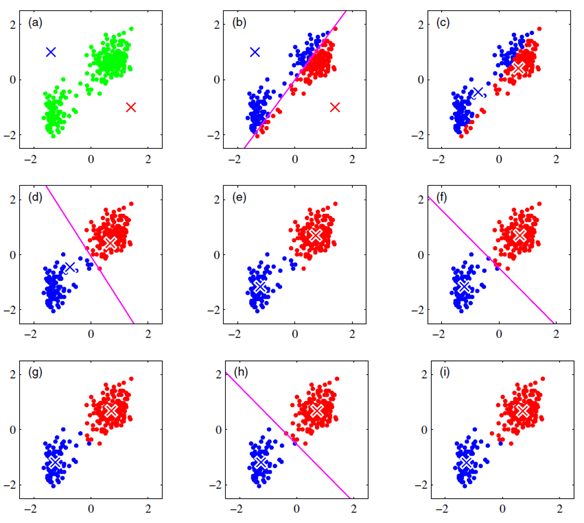

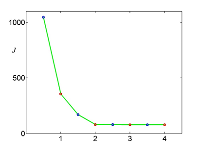

The blue points show the assignment step and the red point show the update step.

Fig source: C.Bishop (2006) Pattern Recognition and Machine Learning. Springer.

### Implementing K-means clustering in Python

To implement the k-means clustering, we can use the `KMeans` class from the `cluster` module in the `sklearn` library.

class sklearn.cluster.KMeans(n_clusters=8, *, init='k-means++', n_init=10, max_iter=300, tol=0.0001, precompute_distances='deprecated', verbose=0, random_state=None, copy_x=True, n_jobs='deprecated', algorithm='auto')

https://scikit-learn.org/stable/modules/generated/sklearn.cluster.KMeans.html

```
from sklearn.cluster import KMeans
import numpy as np

num_clusters = 2
kmeans = KMeans(init="k-means++", n_clusters=num_clusters)
kmeans.fit(x)
```

We can also draw a plot to show the clustering results.

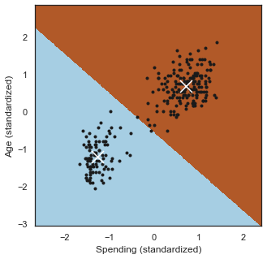

### Pros and cons

**Pros**:

1. Easy to understand
2. Easy to implement
3. Good performance
4. The time complexity is $\mathscr{O}(NKM)$, where $N$ is the total number of observations, $K$ is the number of clusters, and $M$ is the number of iterations. Normally, $K \ll N$ and $M \ll N$. Therefore, the method is relatively scalable and efficient in processing large data sets.

**Cons**:

1. Not guaranteed to converge to the global optimum. The results may depend on the initial random selection of cluster centers.
2. Can be applied only when the mean of a set of objects is defined. This may not be the case in some applications such as when data with nominal attributes are involved.
3. Sensitive to outliers since all data points contribute equally to the mean (i.e., "hard" algorithm).
4. Generate spherical clusters

**Solution to cons 3: soft k-means clustering**

**Input**: $\mathscr{D} = \{\boldsymbol{x}_n\}_{n=1}^{N}$
**Process**:
1: **Choose** some initial values for the $\boldsymbol{\mu}_k$
2: **Minimize** $J$ with respect to $r_{nk}$, keeping the $\boldsymbol{\mu}_k$ fixed:
$$ \hat{k}_n = \textrm{argmin}_{j \in \{1, \cdots, K\}} ||\boldsymbol{x}_n - \boldsymbol{\mu}_j||_2^2, $$ $$ r_{nk} = \frac{\exp\{-\beta ||\boldsymbol{x}_n - \boldsymbol{\mu}_k||_2^2\}}{ \sum_{k=1}^{K} \exp\{-\beta ||\boldsymbol{x}_n - \boldsymbol{\mu}_k||_2^2\}}, \ \ \ \sum_{k=1}^K r_{nk} = 1. $$ 3: **Minimize** $J$ with respect to $\boldsymbol{\mu}_k$, keeping $r_{nk}$ fixed (if $\sum_n r_{nk} = 0$, then we leave the mean $\boldsymbol{\mu}_k$ where it is): $$ \boldsymbol{\mu}_k = \frac{\sum_n r_{nk} \boldsymbol{x}_n }{ \sum_n r_{nk}}. $$ 2: **Repeat** Steps 2 and 3 until $J$ converges.
**Output**: $r_{nk}, \boldsymbol{\mu}_{k}$

Notice the similarity of this soft k-means to the hard k-means. The update step (Step 3) is identical; the only difference is that the responsibilities $r_{nk}$ can take on values between 0 and 1. Whereas the assignment $\hat{k}_n$ is involved a "min" over the distances, the rule for assigning the responsibilities is a "soft-min".

See David MacKay (2003) Information Theory, Inference, and Learning Algorithms. Chapter 20

**Solution to cons 4: mixtures of Gaussians**

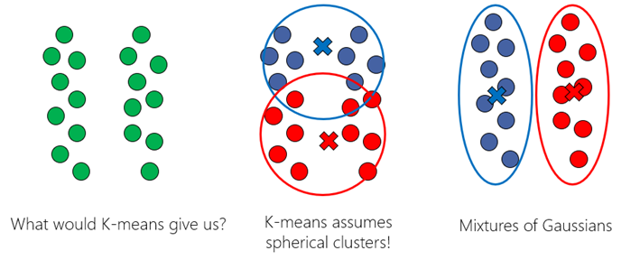